# quarto-inputa8ae3150c8853ce1 – Home

### Selfie Studies

The discussion of “smiling for the camera” is itself part of the larger study of the selfe in social media, a field that is much more developed than you would ever believe. To get an idea of the scope of this field, you could start with the [Selfies Research Network](https://selfieresearchers.com/), founded (as far as I know) by [Theresa Senft](https://researchers.mq.edu.au/en/persons/theresa-m-senft) and other colleagues, notably [Alice Marwick](https://tiara.org/). In light of this week’s reading, you may be struck by Alice’s authentically American smile!

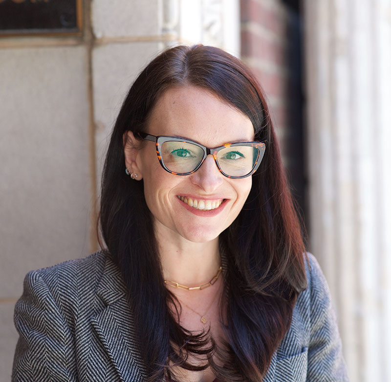

If you’re interested in exploring selfie culture for your research paper, there are many directions you could go, including music video:

[video not shown]

I’ll be interested to see what other examples are brought to mind both by this week’s readings and my lecture!